# quanteda - An Introduction

## Unsupervised ML - STM

The structural topic models (STM) are a popular extension of the standard LDA models. The STM allows to include metadata (the information about each document) into the topicmodel and it offers an alternative initialization mechanism ( *Spectral*). For STMs, the covariates can be used in priors. The `stm` vignette provides a good overview how to use a STM. The package includes estimation algorithms and tools for every stage of the workflow. A particularly large emphasis is on a number of diagnostic functions that are integrated into the R package.

The package `stiminsights` is very useful for visual exploration. It allows the user to process interactive validation, interpretation and visualization of one or several Structural Topic Models (stm).

Again trim `dfm` with `dfm_trim`.

```r
mydfm.un.trim <- dfm_trim(mydfm, min_docfreq = 0.075, max_docfreq = 0.90, docfreq_type = "prop")
```

Assign the number of topics arbitrarily.

```r
topic.count <- 25 # Assigns the number of topics
```

Convert the DFM (with `convert()`) and calculate the STM (with `stm()`).

```r
# Calculate the STM - this takes time! (720 sec)
tic()
dfm2stm <- convert(mydfm.un.trim, to = "stm")

model.stm <- stm(dfm2stm$documents, dfm2stm$vocab, K = topic.count,
                 data = dfm2stm$meta, init.type = "Spectral")
toc()
saveRDS(model.stm, "data/model_stm.rds")
```

To get a first insight, print the terms that appear in each topic.

```r
model.stm <- readRDS("data/model_stm.rds")
as.data.frame(t(labelTopics(model.stm, n = 10)$prob))
```

| V1 | V2 | V3 | V4 | V5 | V6 | V7 | V8 | V9 | V10 | V11 | V12 | V13 | V14 | V15 | V16 | V17 | V18 | V19 | V20 | V21 | V22 | V23 | V24 | V25 |
| --- | --- | --- | --- | --- | --- | --- | --- | --- | --- | --- | --- | --- | --- | --- | --- | --- | --- | --- | --- | --- | --- | --- | --- | --- |
| council | lebanon | soviet | global | african | nuclear | european | trade | african | council | problem | cooper | republ | power | africa | order | problem | israel | island | today | per | terror | america | conflict | africa |
| reform | arab | union | sustain | africa | weapon | europ | economi | situat | iraq | now | stabil | korea | great | south | principl | session | arab | small | war | cent | afghanistan | american | refuge | south |
| effect | resolut | relat | challeng | republ | treati | cooper | product | guinea | resolut | oper | dialogu | democrat | viet | debt | social | oper | palestinian | pacif | live | social | afghan | latin | war | independ |
| activ | problem | militari | chang | democrat | disarma | union | industri | africa | law | negoti | terror | china | deleg | deleg | univers | confer | isra | caribbean | want | educ | cooper | central | somalia | african |
| cooper | territori | forc | climat | millennium | arm | conflict | resourc | particular | aggress | hope | sudan | south | coloni | hope | cultur | solut | palestin | chang | terror | poverti | terrorist | respect | assist | struggl |
| strengthen | palestinian | republ | goal | commit | test | process | increas | hope | charter | agreement | call | korean | territori | process | today | resolut | east | ocean | mani | health | problem | social | humanitarian | regim |
| convent | withdraw | arm | commit | poverti | non | stabil | market | concern | violat | mani | process | asia | nam | environ | life | cyprus | middl | issu | let | drug | global | process | mani | namibia |
| role | principl | war | agenda | particular | prolifer | contribut | price | solut | iraqi | last | promot | north | republ | confer | respect | concern | resolut | sea | now | democraci | asia | solut | elect | apartheid |
| confer | solut | socialist | respons | like | pakistan | bosnia | global | session | islam | way | commit | east | sea | welcom | societi | negoti | occupi | climat | everi | programm | central | possibl | situat | coloni |
| contribut | war | polici | address | summit | india | respect | financi | problem | iran | possibl | issu | cooper | charter | conflict | becom | disarma | territori | call | know | million | issu | express | forc | racist |

The following plot intuitively gets information on the share of the different topics at the overall corpus.

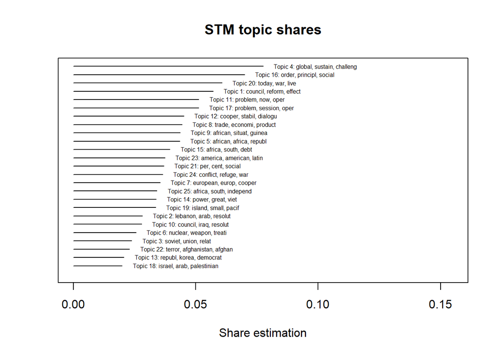

```r
plot(model.stm, type = "summary", text.cex = 0.5, main = "STM topic shares", xlab = "Share estimation")
```

Using `stm`, visualize the different words of a topic with a wordcloud. Since topic 4 has the highest share, use it for the next visualization. The location of the words is randomized and changes each time the wordcloud is ploted while the size of the words is relative to their frequency and remains the same.

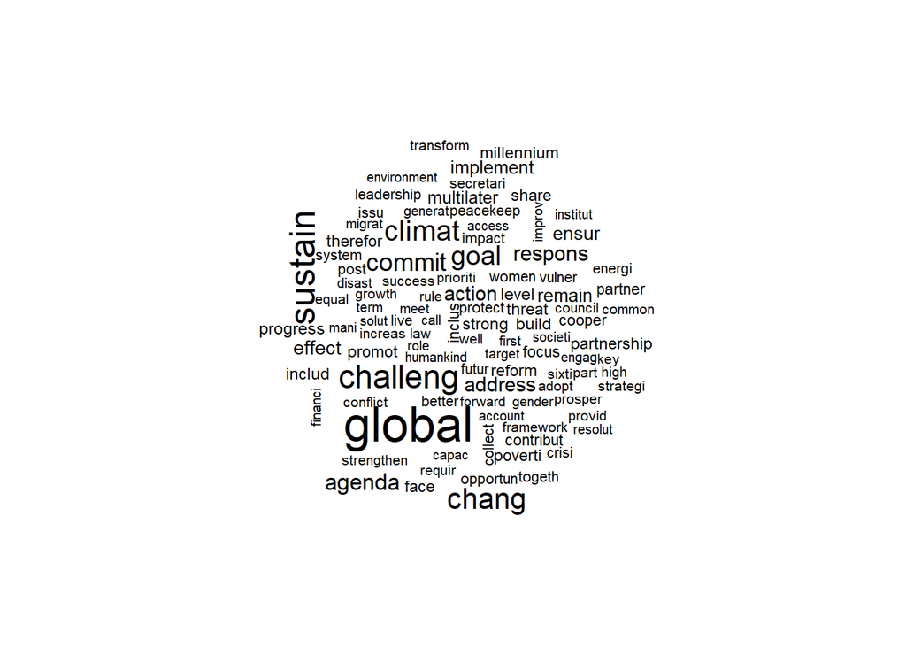

```r
stm::cloud(model.stm, topic = 4, scale = c(2.25, .5))
```

Can also put several different topics in visually perspective using the following lines of code:

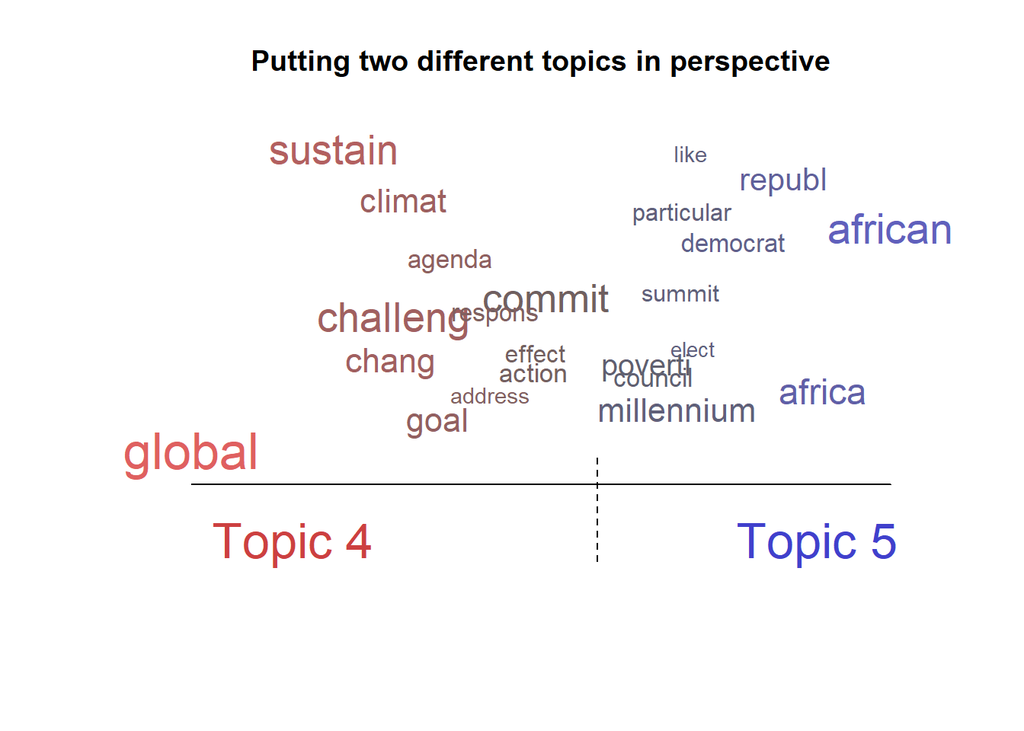

```r
plot(model.stm, type = "perspectives", topics = c(4, 5),
     main = "Putting two different topics in perspective")
```

The perspective plot visualizes the combination of two topics (here topic 4 and topic 5). The size of the words is again relative to their frequency (within the combination of the two topics). The x-axis shows the dregree that specific words align with Topic 4 or Topic 5. Global is closely aligned with Topic 4 whereas commit is more central in both topics.

# Reference

https://www.mzes.uni-mannheim.de/socialsciencedatalab/article/advancing-text-mining/